# Census data transformation

## Normalisation

```r
census_data_norm <-
  census_data_selected %>%
  #
  #----------------------------------------------
  # Popolazione residente
  mutate(P9 = if_else(P4 == 0, 0.5, P9 / P4)) %>%
  mutate(P10 = if_else(P5 == 0, 0.5, P10 / P5)) %>%
  mutate(P11 = if_else(P6 == 0, 0.5, P11 / P6)) %>%
  mutate(P12 = if_else(P7 == 0, 0.5, P12 / P7)) %>%
  mutate(P13 = if_else(P8 == 0, 0.5, P13 / P8)) %>%
  #
  mutate(P30 = if_else(P14 == 0, 0.5, P30 / P14)) %>%
  mutate(P31 = if_else(P15 == 0, 0.5, P31 / P15)) %>%
  mutate(P32 = if_else(P16 == 0, 0.5, P32 / P16)) %>%
  mutate(P33 = if_else(P17 == 0, 0.5, P33 / P17)) %>%
  mutate(P34 = if_else(P18 == 0, 0.5, P34 / P18)) %>%
  mutate(P35 = if_else(P19 == 0, 0.5, P35 / P19)) %>%
  mutate(P36 = if_else(P20 == 0, 0.5, P36 / P20)) %>%
  mutate(P37 = if_else(P21 == 0, 0.5, P37 / P21)) %>%
  mutate(P38 = if_else(P22 == 0, 0.5, P38 / P22)) %>%
  mutate(P39 = if_else(P23 == 0, 0.5, P39 / P23)) %>%
  mutate(P40 = if_else(P24 == 0, 0.5, P40 / P24)) %>%
  mutate(P41 = if_else(P25 == 0, 0.5, P41 / P25)) %>%
  mutate(P42 = if_else(P26 == 0, 0.5, P42 / P26)) %>%
  mutate(P43 = if_else(P27 == 0, 0.5, P43 / P27)) %>%
  mutate(P44 = if_else(P28 == 0, 0.5, P44 / P28)) %>%
  mutate(P45 = if_else(P29 == 0, 0.5, P45 / P29)) %>%
  #
  mutate(P53 = if_else(P46 == 0, 0.5, P53 / P46)) %>%
  mutate(P54 = if_else(P47 == 0, 0.5, P54 / P47)) %>%
  mutate(P55 = if_else(P48 == 0, 0.5, P55 / P48)) %>%
  mutate(P56 = if_else(P49 == 0, 0.5, P56 / P49)) %>%
  mutate(P57 = if_else(P50 == 0, 0.5, P57 / P50)) %>%
  mutate(P58 = if_else(P51 == 0, 0.5, P58 / P51)) %>%
  mutate(P59 = if_else(P52 == 0, 0.5, P59 / P52)) %>%
  #
  mutate(P64 = if_else(P60 == 0, 0.5, P64 / P60)) %>%
  mutate(P65 = if_else(P61 == 0, 0.5, P65 / P61)) %>%
  mutate(P66 = if_else(P62 == 0, 0.5, P66 / P62)) %>%
  #
  mutate(P129 = if_else(P128 == 0, 0.5, P129 / P128)) %>%
  mutate(P132 = if_else(P131 == 0, 0.5, P132 / P131)) %>%
  mutate(P136 = if_else(P135 == 0, 0.5, P136 / P135)) %>%
  mutate(P140 = if_else(P139 == 0, 0.5, P140 / P139)) %>%
  #
  mutate(across(
    P2:P8,
    function(x){if_else(P1 == 0, 0, x / P1)}
  )) %>%
  mutate(across(
    P14:P29,
    function(x){if_else(P1 == 0, 0, x / P1)}
  )) %>%
  mutate(across(
    P46:P52,
    function(x){if_else(P1 == 0, 0, x / P1)}
  )) %>%
  mutate(across(
    P60:P62,
    function(x){if_else(P1 == 0, 0, x / P1)}
  )) %>%
  mutate(P128 = if_else(P1 == 0, 0, P128 / P1)) %>%
  mutate(P130 = if_else(P1 == 0, 0, P130 / P1)) %>%
  mutate(P131 = if_else(P1 == 0, 0, P131 / P1)) %>%
  mutate(P135 = if_else(P1 == 0, 0, P135 / P1)) %>%
  mutate(across(
    P137:P139,
    function(x){if_else(P1 == 0, 0, x / P1)}
  )) %>%
  dplyr::rename_with(
    function(x){ paste0(x, "_norm") },
    P2:P140
  ) %>%
  #
  #----------------------------------------------
  # Stranieri
  mutate(ST6 = if_else(ST3 == 0, 0.5, ST6 / ST3)) %>%
  mutate(ST7 = if_else(ST4 == 0, 0.5, ST7 / ST4)) %>%
  mutate(ST8 = if_else(ST5 == 0, 0.5, ST8 / ST5)) %>%
  #
  mutate(across(
    ST2:ST5,
    function(x){if_else(ST1 == 0, 0, x / ST1)}
  )) %>%
  mutate(across(
    ST9:ST10_ST11_ST12_ST13_ST14,
    function(x){if_else(ST1 == 0, 0, x / ST1)}
  )) %>%
  dplyr::rename_with(
    function(x){ paste0(x, "_norm") },
    ST2:ST10_ST11_ST12_ST13_ST14
  ) %>%
  mutate(ST1 = if_else(P1 == 0, 0, ST1 / P1)) %>%
  rename(ST1_norm = ST1) %>%
  #
  #----------------------------------------------
  # Abitazioni
  # Sum all A2 to A7 values for normalisation then remove
  mutate(A1_guess = A2 + A3 + A5_A6_A7) %>%
  mutate(across(
    A2:A5_A6_A7,
    function(x){if_else(A1_guess == 0, 0, x / A1_guess)}
  )) %>%
  dplyr::rename_with(
    function(x){ paste0(x, "_norm") },
    A2:A5_A6_A7
  ) %>%
  select(-A1_guess) %>%
  #
  #----------------------------------------------
  # Famiglie in alloggi
  mutate(across(
    A46:A48,
    function(x){if_else(PF1 == 0, 0, x / PF1)}
  )) %>%
  dplyr::rename_with(
    function(x){ paste0(x, "_norm") },
    A46:A48
  ) %>%
  #
  #----------------------------------------------
  # Famiglie
  mutate(across(
    PF2:PF7_PF8,
    function(x){if_else(PF1 == 0, 0, x / PF1)}
  )) %>%
  dplyr::rename_with(
    function(x){ paste0(x, "_norm") },
    PF2:PF7_PF8
  ) %>%
  #
  #----------------------------------------------
  # Edifici
  # and normalisation results in a very long left tail, not used
  mutate(across(
    E3:E30_E31,
    function(x){if_else(E1 == 0, 0, x / E1)}
  )) %>%
  dplyr::rename_with(
    function(x){ paste0(x, "_norm") },
    E3:E30_E31
  ) %>%
  #
  #----------------------------------------------
  # Area-based normalisations
  mutate(across(
    all_of(c("P1", "PF1", "E1")),
    function(x){x / sez_area_km2}
  )) %>%
  mutate(
    A44 = A44 / (sez_area_km2 * 1000000)
  ) %>%
  dplyr::rename_with(
    function(x){ paste0(x, "_norm") },
    all_of(c("P1", "PF1", "A44", "E1"))
  ) %>%
  select(-sez_area_km2)
```

Double-check missing values and `NaN`.

```r
census_data_norm %>%
  filter(if_any(P1_norm:E30_E31_norm, ~is.na(.))) %>%
  count() %>%
  pull(n)
```

```
## [1] 0
```

```r
census_data_norm %>%
  filter(if_any(P1_norm:E30_E31_norm, ~is.nan(.))) %>%
  count() %>%
  pull(n)
```

```
## [1] 0
```

No missing values nor `NaN`.

## Skewness

```r
census_data_norm_skewness <-
  census_data_norm %>%
  select(P1_norm:E30_E31_norm) %>%
  summarise(across(P1_norm:E30_E31_norm, skewness)) %>%
  pivot_longer(P1_norm:E30_E31_norm, names_to = "variable", values_to = "skewness")

census_data_norm_skewness %>%
  slice_max(order_by = skewness, n = 10)
```

```
## # A tibble: 10 × 2
##    variable  skewness
##    <chr>        <dbl>
##  1 E1_norm     456.
##  2 PF1_norm    373.
##  3 P1_norm     355.
##  4 A44_norm    323.
##  5 P52_norm     14.2
##  6 P6_norm      11.9
##  7 E27_norm     11.4
##  8 P8_norm      11.1
##  9 P62_norm      8.40
## 10 P135_norm     6.81
```

```r
census_data_norm_skewness %>%
  slice_min(order_by = skewness, n = 10)
```

```
## # A tibble: 10 × 2
##    variable  skewness
##    <chr>        <dbl>
##  1 P46_norm    -2.53
##  2 E3_norm     -1.81
##  3 A47_norm    -1.40
##  4 P3_norm     -1.00
##  5 A2_norm     -0.644
##  6 P5_norm     -0.426
##  7 ST8_norm    -0.351
##  8 ST7_norm    -0.180
##  9 P136_norm   -0.153
## 10 ST6_norm    -0.104
```

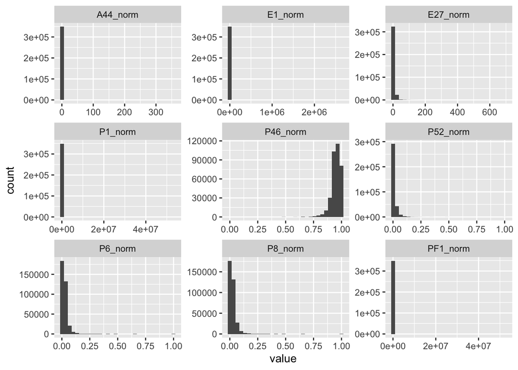

```r
census_data_norm %>%
  select(
    E1_norm, PF1_norm, P1_norm,
    A44_norm, P52_norm, P6_norm,
    E27_norm, P8_norm, P46_norm
  ) %>%
  pivot_longer(everything(), names_to = "variable", values_to = "value") %>%
  ggplot(aes(x = value)) +
  geom_histogram() +
  facet_wrap(~variable, scales = "free")
```

Apply a `log10` transformation to all variables with skewness above 2 or below -2.

```r
skewed_vars <-
  census_data_norm_skewness %>%
  filter(skewness > 2 | skewness < -2) %>%
  pull(variable)

census_data_norm_unskewed <-
  census_data_norm %>%
  mutate(
    across(
      all_of(skewed_vars),
      # use +1 to shift the log10 curve
      function(x)(log10(x+1))
    )
  ) %>%
  dplyr::rename_with(
    function(x){ paste0(x, "_log10") },
    all_of(skewed_vars)
  )
```

```r
census_data_norm_unskewed %>%
  select(P1_norm_log10:E30_E31_norm_log10) %>%
  summarise(across(P1_norm_log10:E30_E31_norm_log10, skewness)) %>%
  pivot_longer(P1_norm_log10:E30_E31_norm_log10, names_to = "variable", values_to = "skewness") %>%
  slice_max(order_by = skewness, n = 10)
```

```
## # A tibble: 10 × 2
##    variable        skewness
##    <chr>              <dbl>
##  1 P52_norm_log10     10.1
##  2 P6_norm_log10       8.50
##  3 P8_norm_log10       7.84
##  4 P62_norm_log10      5.55
##  5 P135_norm_log10     4.89
##  6 P27_norm_log10      4.32
##  7 P28_norm_log10      4.28
##  8 P25_norm_log10      4.00
##  9 P26_norm_log10      3.91
## 10 P19_norm_log10      3.72
```

```r
census_data_norm_unskewed %>%
  select(P1_norm_log10:E30_E31_norm_log10) %>%
  summarise(across(P1_norm_log10:E30_E31_norm_log10, skewness)) %>%
  pivot_longer(P1_norm_log10:E30_E31_norm_log10, names_to = "variable", values_to = "skewness") %>%
  slice_min(order_by = skewness, n = 10)
```

```
## # A tibble: 10 × 2
##    variable       skewness
##    <chr>             <dbl>
##  1 P46_norm_log10   -3.15
##  2 E3_norm          -1.81
##  3 A47_norm         -1.40
##  4 E1_norm_log10    -1.21
##  5 P1_norm_log10    -1.08
##  6 P3_norm          -1.00
##  7 PF1_norm_log10   -0.978
##  8 A2_norm          -0.644
##  9 P5_norm          -0.426
## 10 ST8_norm         -0.351
```

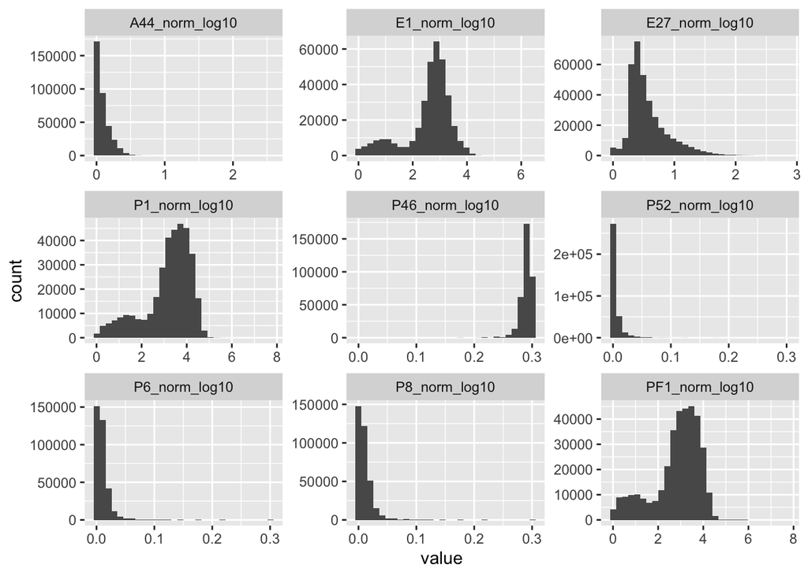

```r
census_data_norm_unskewed %>%
  select(
    E1_norm_log10, PF1_norm_log10, P1_norm_log10,
    A44_norm_log10, P52_norm_log10, P6_norm_log10,
    E27_norm_log10, P8_norm_log10, P46_norm_log10
  ) %>%
  pivot_longer(everything(), names_to = "variable", values_to = "value") %>%
  ggplot(aes(x = value)) +
  geom_histogram() +
  facet_wrap(~variable, scales = "free")
```

## Standardisation

```r
census_data_norm_unskewed_std <-
  census_data_norm_unskewed %>%
  mutate(
    across(
      P1_norm_log10:E30_E31_norm_log10,
      function(x){ scale(x) %>% as.vector() }
    )
  ) %>%
  dplyr::rename_with(
    function(x){ paste0(x, "_std") },
    P1_norm_log10:E30_E31_norm_log10
  )
```

## Final overview

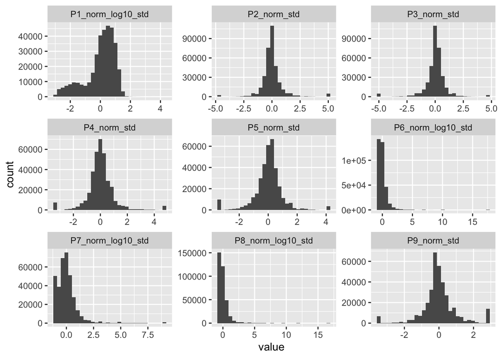

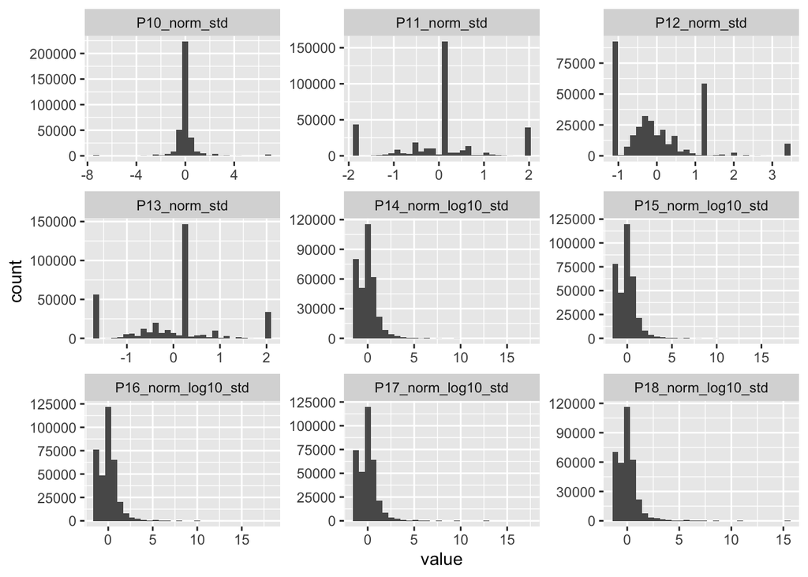

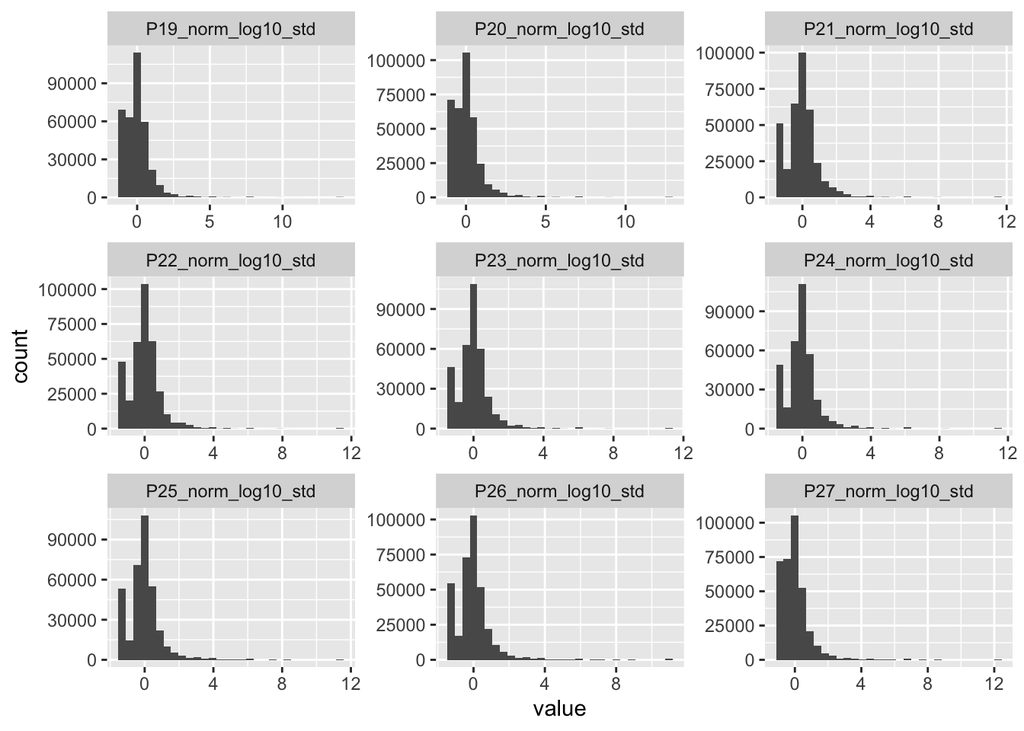

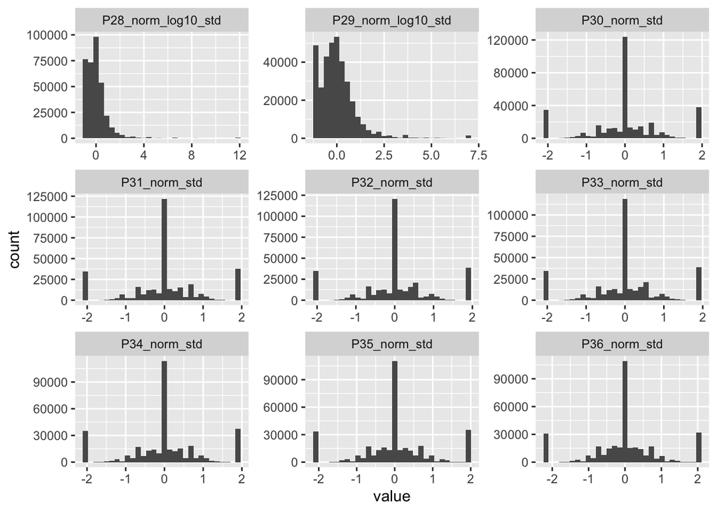

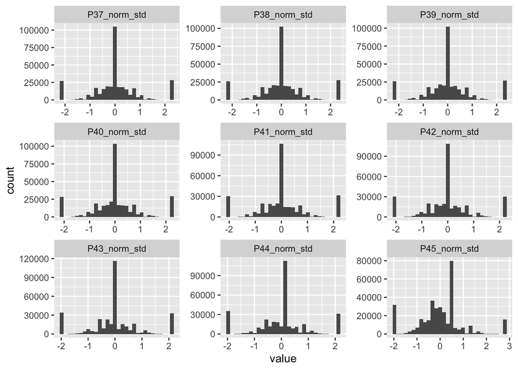

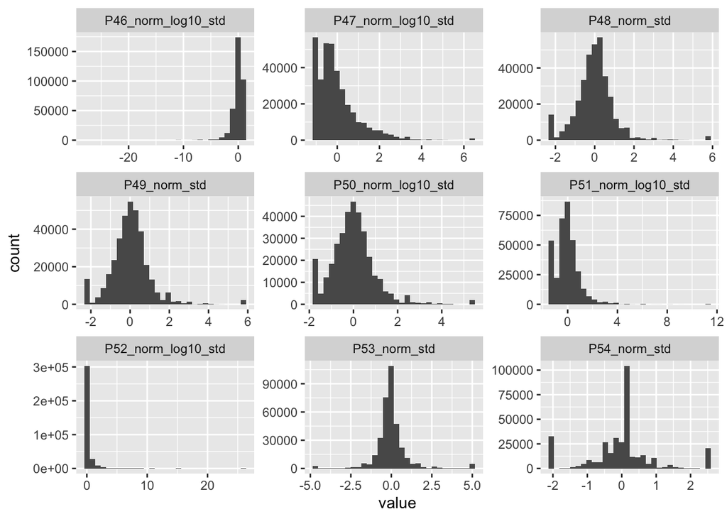

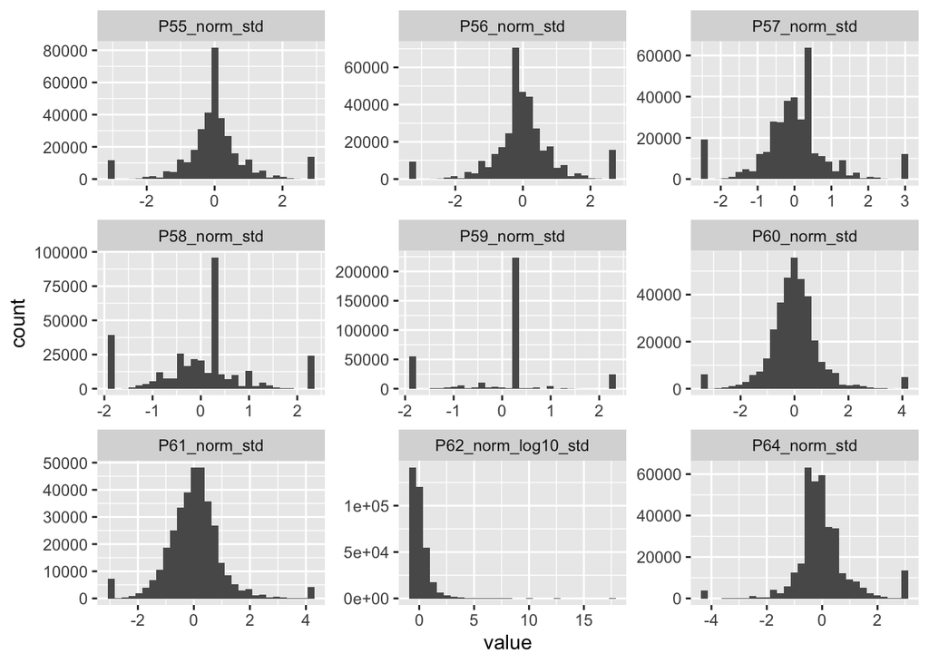

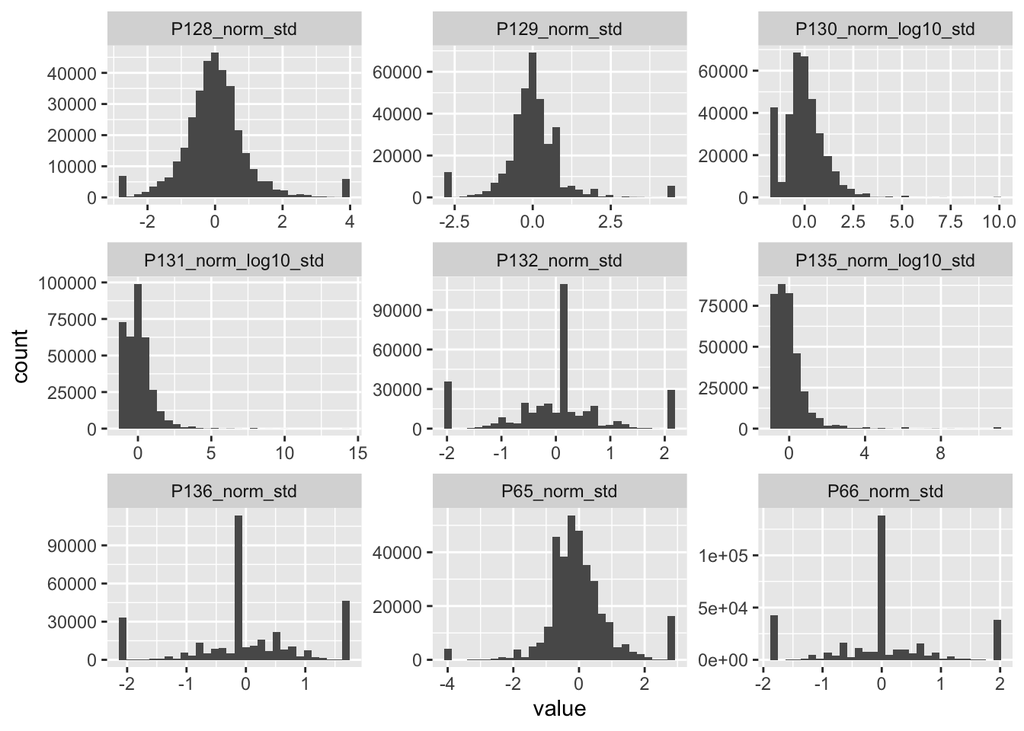

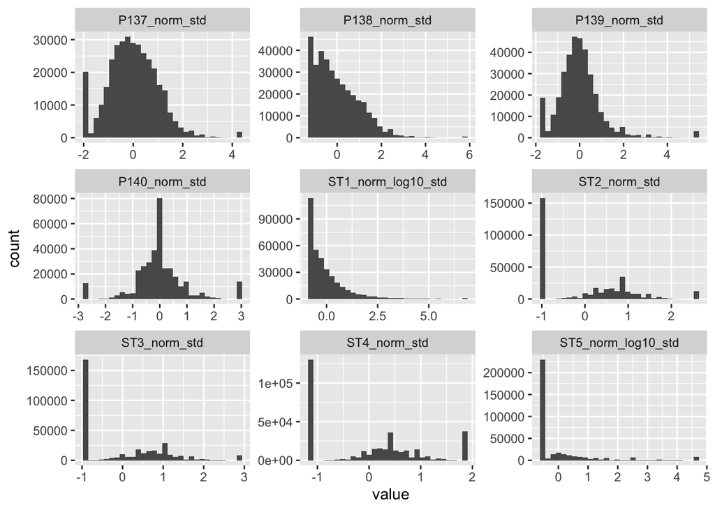

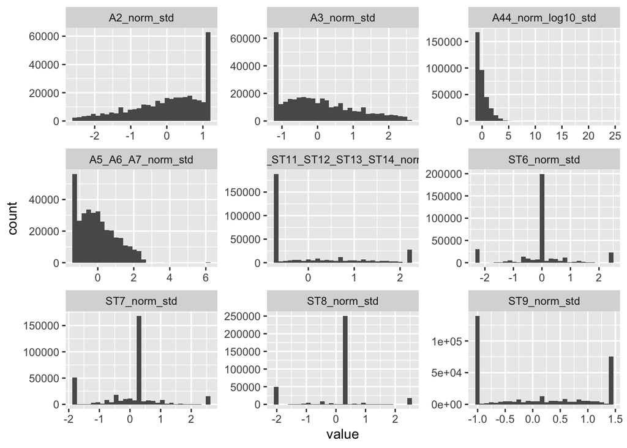

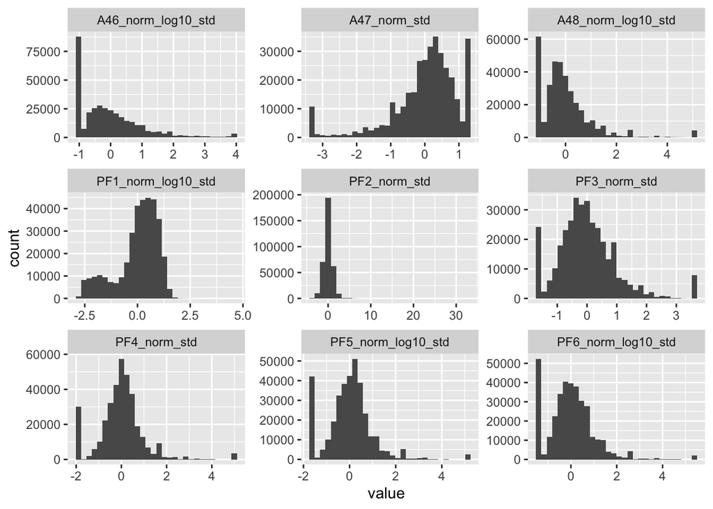

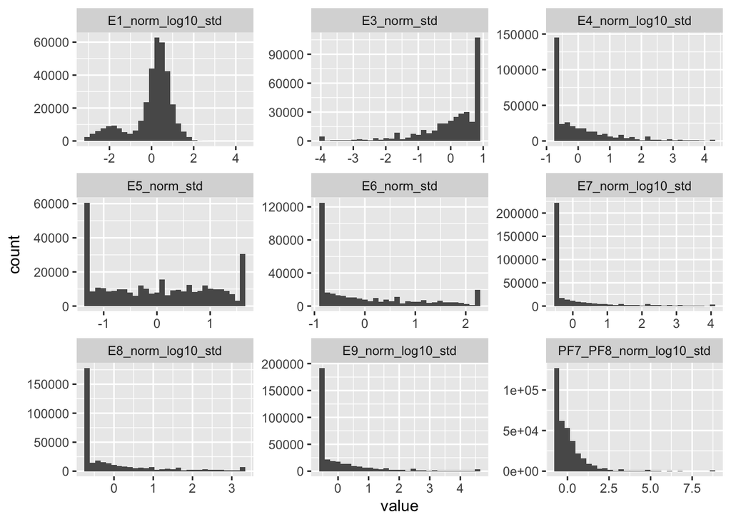

[2 more figures not shown]

```r
vars_names <-
  census_data_norm_unskewed_std %>%
  select(P1_norm_log10_std:E30_E31_norm_log10_std) %>%
  colnames()

for (i in 0:floor(length(vars_names)/9)) {
  i_range <- (1+(9*i)):min((9+(9*i)), length(vars_names))
  i_plot <-
    census_data_norm_unskewed_std %>%
    select(all_of(vars_names[i_range])) %>%
    pivot_longer(everything(), names_to = "variable", values_to = "value") %>%
    ggplot(aes(x = value)) +
    geom_histogram() +
    facet_wrap(~variable, scales = "free")
  print(i_plot)
  rm(i_range, i_plot)
}
```

## Save new values

```r
colnames(census_data_norm_unskewed_std)
```

```
##   [1] "CODREG"                            "REGIONE"
##   [3] "CODPRO"                            "PROVINCIA"
##   [5] "CODCOM"                            "COMUNE"
##   [7] "PROCOM"                            "SEZ2011"
##   [9] "NSEZ"                              "ACE"
##  [11] "CODLOC"                            "CODASC"
##  [13] "P1_norm_log10_std"                 "P2_norm_std"
##  [15] "P3_norm_std"                       "P4_norm_std"
##  [17] "P5_norm_std"                       "P6_norm_log10_std"
##  [19] "P7_norm_log10_std"                 "P8_norm_log10_std"
##  [21] "P9_norm_std"                       "P10_norm_std"
##  [23] "P11_norm_std"                      "P12_norm_std"
##  [25] "P13_norm_std"                      "P14_norm_log10_std"
##  [27] "P15_norm_log10_std"                "P16_norm_log10_std"
##  [29] "P17_norm_log10_std"                "P18_norm_log10_std"
```

[output cut: 54 more lines]

```r
census_data_norm_unskewed_std %>%
  write_csv("../storage/dati-cpa_2011_all-trans-v0_0_3.csv")
```

## Conclusions

This is a **draft**, the analysis is still on-going.

There is still a lot of very skewed variables. Those will probably need to be combined or dropped.

## Acknowledgements

This analysis uses data from [ISTAT](https://www.istat.it/it/archivio/104317) distributed under [CC BY 3.0 IT](https://creativecommons.org/licenses/by/3.0/it/deed.en) (see also [legal notice](https://www.istat.it/it/note-legali)).